# Ridge Regression

Caroline Svahn & Martina Sandberg

2015-10-16

# Ridgereg and the caret package

## 1.

Divide the `BostonHousing` data into a test and a training dataset using the `caret` package.

```r
library(RLab4)
library(mlbench)
library(caret)
data(BostonHousing)

trainIndex <- createDataPartition(BostonHousing$medv, p = .8, list = FALSE,times = 1)

Train <- BostonHousing[ trainIndex,]
Test  <- BostonHousing[-trainIndex,]
```

## 2.

Fit a linear regression model and a linear regression model with forward selection of covariates on the training dataset.

```r
 model1 <- train(medv ~ crim + indus + zn + chas +
                  nox + rm + age + dis + rad + tax + ptratio
                + b + lstat , data=Train , method = 'lm')
```

```r
model2 <- train(medv ~ crim + indus + zn + chas +
                  nox + rm + age + dis + rad + tax + ptratio
                + b + lstat , data=Train , method = 'leapForward')
summary(model2)
```

```
## Subset selection object
## 13 Variables  (and intercept)
##         Forced in Forced out
## crim        FALSE      FALSE
## indus       FALSE      FALSE
## zn          FALSE      FALSE
## chas1       FALSE      FALSE
## nox         FALSE      FALSE
## rm          FALSE      FALSE
## age         FALSE      FALSE
## dis         FALSE      FALSE
## rad         FALSE      FALSE
## tax         FALSE      FALSE
## ptratio     FALSE      FALSE
## b           FALSE      FALSE
## lstat       FALSE      FALSE
## 1 subsets of each size up to 4
## Selection Algorithm: forward
##          crim indus zn  chas1 nox rm  age dis rad tax ptratio b   lstat
## 1  ( 1 ) " "  " "   " " " "   " " " " " " " " " " " " " "     " " "*"
## 2  ( 1 ) " "  " "   " " " "   " " "*" " " " " " " " " " "     " " "*"
## 3  ( 1 ) " "  " "   " " " "   " " "*" " " " " " " " " "*"     " " "*"
## 4  ( 1 ) " "  " "   " " " "   " " "*" " " "*" " " " " "*"     " " "*"
```

```r
model2 <- train(medv ~ rm + dis + ptratio + lstat , data=Train , method = 'lm')
```

## 3.

Evaluate the performance of these two models on the training dataset.

```r
summary(model1)
```

```
##
## Call:
## lm(formula = .outcome ~ ., data = dat)
##
## Residuals:
##      Min       1Q   Median       3Q      Max
## -13.6501  -2.7110  -0.5075   1.6991  25.6242
##
## Coefficients:
##               Estimate Std. Error t value Pr(>|t|)
## (Intercept)  43.418566   5.769505   7.526 3.62e-13 ***
## crim         -0.117203   0.048508  -2.416 0.016139 *
## indus         0.008085   0.072289   0.112 0.911004
## zn            0.050584   0.015064   3.358 0.000862 ***
## chas1         2.991487   0.974552   3.070 0.002292 **
## nox         -19.917197   4.270705  -4.664 4.26e-06 ***
## rm            3.133040   0.474001   6.610 1.26e-10 ***
## age           0.002939   0.014251   0.206 0.836717
## dis          -1.570388   0.216608  -7.250 2.23e-12 ***
## rad           0.302284   0.075615   3.998 7.64e-05 ***
## tax          -0.012428   0.004294  -2.894 0.004010 **
## ptratio      -1.002061   0.146826  -6.825 3.35e-11 ***
## b             0.008392   0.003095   2.712 0.006990 **
## lstat        -0.523824   0.055972  -9.359  < 2e-16 ***
## ---
## Signif. codes:  0 '***' 0.001 '**' 0.01 '*' 0.05 '.' 0.1 ' ' 1
##
## Residual standard error: 4.722 on 393 degrees of freedom
## Multiple R-squared:  0.7286, Adjusted R-squared:  0.7196
## F-statistic: 81.16 on 13 and 393 DF,  p-value: < 2.2e-16
```

```r
summary(model2)
```

```
##
## Call:
## lm(formula = .outcome ~ ., data = dat)
##
## Residuals:
##     Min      1Q  Median      3Q     Max
## -14.013  -3.149  -0.625   1.884  26.936
##
## Coefficients:
##             Estimate Std. Error t value Pr(>|t|)
## (Intercept)  28.3751     4.6030   6.164 1.72e-09 ***
## rm            3.7385     0.4797   7.794 5.62e-14 ***
## dis          -0.5304     0.1370  -3.872 0.000126 ***
## ptratio      -1.0267     0.1291  -7.950 1.91e-14 ***
## lstat        -0.6685     0.0520 -12.857  < 2e-16 ***
## ---
## Signif. codes:  0 '***' 0.001 '**' 0.01 '*' 0.05 '.' 0.1 ' ' 1
##
## Residual standard error: 5.14 on 402 degrees of freedom
## Multiple R-squared:  0.671,  Adjusted R-squared:  0.6677
## F-statistic:   205 on 4 and 402 DF,  p-value: < 2.2e-16
```

In model 1 there is some non-significant parameters but in model 2 all parameters are significant. The R-squared are slightly better in model 1 and the residual standard error is also better in model 1. The p-value of the F-statistics are the same in both models. Because of the small differences between the models we would choose model 2 because it is smaller than model 1.

## 4.

Fit a ridge regression model using your `ridgereg()` function to the training dataset.

```r
RidgeModel <- list(type=c("Regression"), library="RLab4",loop=NULL)
par <- data.frame(parameter="lambda", class="numeric",label="Lambda")
RidgeModel$parameters <- par

grid <- function(x, y, len = NULL, search = "grid"){
  if(search == "grid") {
    out <- expand.grid(lambda = c(0, 10 ^ seq(-1, -4, length = len - 1)))
  } else {
    out <- data.frame(lambda = 10^runif(len, min = -5, 1))
  }
  out
}
RidgeModel$grid <- grid

list_fit <- function(x, y, lambda, param, lev, last, classProbs, ...){
  data <- as.data.frame(x)
  data$response <- y

  formula <- "response ~ "
  cov <- capture.output(cat(colnames(data), sep="+"))
  formula <- paste(formula, cov)
  formula <- as.formula(formula)

  RLab4::ridgereg(formula=formula, data=data, lambda=param$lambda)
}
RidgeModel$fit <- list_fit

pred <- function(modelFit, newdata, preProc=NULL, submodels=NULL){
  # RLab4::modelFit$predict(newdata)
  # predict(modelFit, newdata)
}
RidgeModel$predict <- pred

prob<- list(NULL)
RidgeModel$prob <- prob

RidgeModel$label <- "Ridgeregression"
```

```r
model3 <- train(medv ~ crim + indus + zn + chas +
                  nox + rm + age + dis + rad + tax + ptratio
                + b + lstat,data=Train,
                   method = "ridge")
model3
```

```
## Ridge Regression
##
## 407 samples
##  13 predictor
##
## No pre-processing
## Resampling: Bootstrapped (25 reps)
## Summary of sample sizes: 407, 407, 407, 407, 407, 407, ...
## Resampling results across tuning parameters:
##
##   lambda  RMSE      Rsquared   RMSE SD    Rsquared SD
##   0e+00   5.020726  0.6903420  0.2987166  0.04113220
##   1e-04   5.020652  0.6903518  0.2988031  0.04114143
##   1e-01   5.064716  0.6876345  0.3712481  0.04663968
##
## RMSE was used to select the optimal model using  the smallest value.
## The final value used for the model was lambda = 1e-04.
```

Find the best hyperparameter value for lambda using 10-fold cross-validation.

```r
fitControl <- trainControl(method = "repeatedcv",number = 10,repeats = 10)
model4 <- train(medv ~ crim + indus + zn + chas +
                  nox + rm + age + dis + rad + tax + ptratio
                + b + lstat,data=Train,
                method = "ridge",
                trControl = fitControl)
model4
```

```
## Ridge Regression
##
## 407 samples
##  13 predictor
##
## No pre-processing
## Resampling: Cross-Validated (10 fold, repeated 10 times)
## Summary of sample sizes: 367, 367, 365, 367, 366, 366, ...
## Resampling results across tuning parameters:
##
##   lambda  RMSE      Rsquared   RMSE SD    Rsquared SD
##   0e+00   4.817674  0.7106080  0.8430368  0.08988639
##   1e-04   4.817614  0.7106156  0.8432132  0.08990470
##   1e-01   4.853299  0.7085692  0.9555580  0.10196009
##
## RMSE was used to select the optimal model using  the smallest value.
## The final value used for the model was lambda = 1e-04.
```

## 5.

Evaluate the performance on the training dataset. (Fit a linear model with the best lambda=0.0001.)

```r
model5 <- ridgereg(medv ~ crim + indus + zn + chas +
           nox + rm + age + dis + rad + tax + ptratio
         + b + lstat , data=Train , 0.0001)
```

```r
model5$summary()
```

```
## $Coefficients
##                Estimate Std.Error    t value       p value
## (Intercept) 22.53611240 0.2340615 96.2828575 2.155939e-275
## crim        -0.83337458 0.3449148 -2.4161754  1.613953e-02
## indus        0.05475558 0.4895986  0.1118377  9.110092e-01
## zn           1.22057515 0.3635012  3.3578298  8.622487e-04
## chas1        0.74541965 0.2428389  3.0696056  2.292188e-03
## nox         -2.33714033 0.5011376 -4.6636700  4.263676e-06
## rm           2.15860952 0.3265779  6.6097853  1.256665e-10
## age          0.08295224 0.4022345  0.2062286  8.367192e-01
## dis         -3.36742149 0.4644787 -7.2498938  2.231560e-12
## rad          2.58364026 0.6462851  3.9976787  7.640673e-05
## tax         -2.06071381 0.7119502 -2.8944635  4.009855e-03
## ptratio     -2.15658532 0.3159920 -6.8248093  3.346831e-11
## b            0.73720249 0.2718701  2.7115981  6.989834e-03
## lstat       -3.66919375 0.3920635 -9.3586719  6.304819e-19
##
## $degrees_of_freedom
## [1] 393
##
## $residual_standard_error
## [1] 4.722014
```

## 6.

Evaluate the performance of all three models on the test dataset and write some concluding comments.

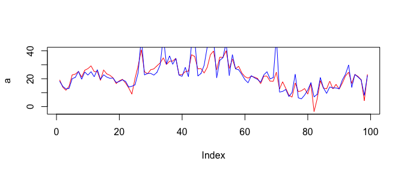

```r
a <- predict(model1, newdata = Test)
plot(a,type="l",col="red")
lines(Test$medv, col="blue")
```

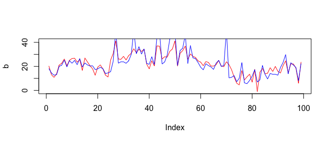

```r
b <- predict(model2, newdata = Test)
plot(b,type="l",col="red")
lines(Test$medv, col="blue")
```

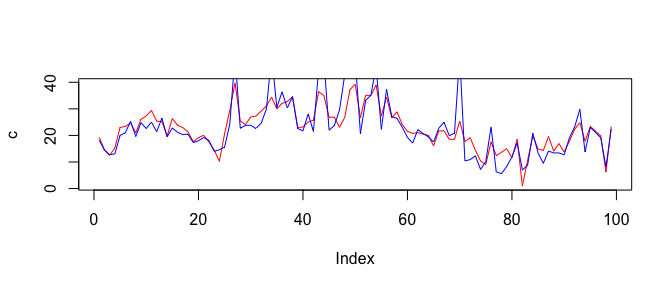

```r
c <- model5$predict(data=Test)
plot(c,type="l",col="red")
lines(Test$medv, col="blue")
```

```r
rmse <- function(error){
  sqrt(mean(error^2))
}
error1 <- a-Test$medv
rmse(error1)
```

```
## [1] 4.9411
```

```r
error2 <- b-Test$medv
rmse(error2)
```

```
## [1] 5.180769
```

```r
error3 <- c-Test$medv
rmse(error3)
```

```
## [1] 5.141107
```

we can see that the models perform quite equal. We would prefer model 2 because it is the smallest model which is easier to work with.